# Propensity Score Methods

Univeristy of Michigan Biostatistics 699, Winter 2022

## Sources

- Content derived from earlier 699 presentations (by Matt Schipper, Brisa Sanchez, Jeremy Taylor) and Jean Morrison’s 881 slides
- Also lots of references (cited throughout)

## Randomized two-group experiment

- Subjects are assigned in equal proportions to one of two treatment arms, \(Z\in\{0,1\}\)
- Some outcome \(Y\) is measured, and interest is in estimating the difference in the average outcome between the two groups
- As long as assignments are randomized, the estimated difference in outcomes would be a good estimate of the *average treatment effect* (ATE): the difference in average outcomes if everyone in the population got the treatment versus if everyone didn’t
- This is true even in presence of other predictors \(X\) that influence outcome

But when \(X\) drives choice of treatment assignment, then difference in average outcomes no longer estimates ATE, due to confounding:

[interactive chart not shown]

## General goal

You are interested in estimating the ATE but have observational data, i.e. the treatment is not randomized

Strategically analyze / manipulate the data you have so that result mimics what you would get from randomized trial

## Propensity scores

Propensity score defined as \(e(X) = \Pr(Z=1|X)\)

- In clinical trials, this is known
- In present context, we estimate this using our data

## Balancing property of propensity scores

### Theorem 1, Rosenbaum and Rubin (1983)

\(\{Z\perp X\} | e(X)\)

In words, \(Z\) is conditionally independent of predictors \(X\) given (true) propensity score. Consequences of this are:

- If you know true propensity for treatment, you learn nothing additional about treatment assignment were you to have full set of predictors \(X\).
- You would expect distribution of \(X\)s to be identical between treatment arms among observations with common value of \(e(X)\)
- For observations with a common value of \(e(X)\), you can analyze outcomes as if they come from randomized trial with randomization probability \(e(X)\)

## Using propensity score

Several approaches for

1. Adjusting for PS
2. Stratifying
3. Matching
4. Weighting

See Franklin et al. (2017) for helpful overview

## 1. Adjusting for PS

A randomized study with a common treatment assignment probability might analyze data as

\[\mathrm{logit}(E[Y|Z]) = \beta_0 + \beta_1 Z\]

If you “know” (i.e. have estimated) treatment propensity \(e\), then you might instead use

\[\mathrm{logit}(E[Y|Z,e]) = \beta_0 + \beta_1 Z + f(e)\] where \(f\) is some function that is estimated (could be linear, could be more flexible).

Estimate of ATE would be average expected outcome if all subjects were in one group minus same average if all subjects were in other group: \[\frac{1}{n}\sum_{i=1}^n ({\hat E}[Y_i|Z_i=1,e_i] - {\hat E}[Y_i|Z_i=1,e_i])\]

## 2. Stratifying

1. Identify subgroups of observations with “similar” propensity values to create multiple strata
2. Calculate observation-specific weights: \(w_i = \dfrac{n_s n_z}{n_{zs} n}\). This is empiric estimate of \(\Pr(Z=z) / \Pr(Z=z|S=s)\)
3. Then estimate treatment effect by \[ \dfrac{\sum_{i:Z_i=1} w_i Y_i}{\sum_{i:Z_i=1} w_i}-\dfrac{\sum_{i:Z_i=0} w_i Y_i}{\sum_{i:Z_i=0} w_i}\]

or estimate logistic regression model with maximum *weighted* log-likelihood

## 3. Matching

1. Randomly select a treated (\(Z=1\)) subject
2. Pair with comparator (\(Z=0\)) subject with closest propensity score (within some distance). Otherwise discard
3. Repeat until all treated subjects have been paired or discarded.
4. Estimate treatment effect **in matched dataset** by \[ \dfrac{\sum_{i:Z_i=1} Y_i}{\sum_{i:Z_i=1} 1 }-\dfrac{\sum_{i:Z_i=0} Y_i}{\sum_{i:Z_i=0}1 }\]

or estimate logistic regression model with maximum log-likelihood

Matching process implemented in `MatchIt` package in `R`

## 4. Weighting

1. Inverse propensity of treatment weights (IPW or IPTW) defined by \(w_i = Z_i / e_i + (1 - Z_i) / (1 - e_i)\), which is inverse probability of receiving treatment that was actually received
2. Estimate treatment effect by \[ \dfrac{\sum_{i:Z_i=1} w_i Y_i}{\sum_{i:Z_i=1} w_i}-\dfrac{\sum_{i:Z_i=0} w_i Y_i}{\sum_{i:Z_i=0} w_i}\]

or estimate logistic regression model with maximum *weighted* log-likelihood

## Inspecting balance

Stratifying, matching, and weighting all yield synthetic population that can be described or analyzed as if it were randomized

It can be helpful to inspect covariate distribution between treatments in synthetic population across covariates to ensure that balance has been induced

## Absolute weighted standardized difference as measure of balance

\[d(X,w) = 100 \times \dfrac{|\bar{X}^w_{Z=1} - \bar{X}^w_{Z=0}|}{\sqrt{(s^{w}_{Z=1})^2/2 + (s^w_{Z=0})^2/2}}\] Note that denominator is standard deviation not standard error. Simple diagnostic is that \(d > 10\%\) suggests un-captured confounding by that variable

Main idea is that with proper choice of weights, \(d\) should improve, i.e. go to zero.

\(\bar{X}^w_{Z=z} = \sum_{Z=z} w_i X_i / \sum_{Z=z} w_i\) and \((s^{w}_{Z=z})^2 = \frac{\sum_{Z=z} w_i}{(\sum_{Z=z} w_i)^2 - \sum_{Z=z} w_i^2}\sum_{Z=z} w_i(X_i - \bar{X}^w_{Z=z})^2\)

Flury and Riedwyl (1986), Austin and Stuart (2015), Austin (2009)

## SUPPORT: Right-heart catheterization data from Connors et al. (1996)

5735 acutely ill patients admitted to one of 5 large hospitals

Treatment (\(Z\)) was right-heart catheterization procedure

Outcome (\(Y\)) was patient death within 30 days

Other possible confounders (\(X\)) were 32 predictors measuring patient demographics, primary diagnosis, and comorbidities

See also: https://www.ofcaus.org/data-examples/ipw-dr https://hbiostat.org/data/repo/rhc.html

## Our tasks

1. Estimate propensities with multivariable logistic regression
2. Inspect distribution of propensities in each treatment group
3. Apply four approaches
1. Inspect balance
2. Compare estimates of treatment effect

```r
rhc <-
  read_csv("rhc.csv", show_col_types = FALSE) %>%
  mutate(income = as_factor(income),
         cat1 = as_factor(cat1),
         cat2 = as_factor(cat2)) %>%
  rename(subjid = id)

predictors <- setdiff(colnames(rhc),
                      c("subjid",
                        "swang1", #treatment
                        "dth30" #outcome
                      ))

ps_formula <-
  as.formula(paste0("swang1 ~",paste0(predictors, collapse = "+")))

ps_model <-
  glm(ps_formula, family = "binomial", data = rhc)

rhc_ps <-
  bind_cols(rhc %>% select(subjid, swang1, dth30),
            model.matrix(ps_model)[,-1],
            ps_swang1 = predict(ps_model, type = "response", newdata = rhc))

predictors <- colnames(model.matrix(ps_model)[,-1])
```

Fitted propensity model sorted by significance:

```r
tidy(ps_model) %>%
  arrange(desc(abs(statistic))) %>%
  print(n = Inf)
```

```
## # A tibble: 33 × 5
##    term        estimate std.error statistic  p.value
##    <chr>          <dbl>     <dbl>     <dbl>    <dbl>
##  1 surv2md1    -4.19     0.338      -12.4   2.73e-35
##  2 cat14       -1.52     0.187       -8.12  4.71e-16
##  3 wtkilo1      0.0107   0.00142      7.51  5.69e-14
##  4 transhx      0.666    0.0943       7.06  1.61e-12
##  5 neuro       -0.833    0.124       -6.74  1.63e-11
##  6 dnr1        -0.721    0.110       -6.57  5.05e-11
##  7 resp        -0.472    0.0725      -6.52  7.10e-11
##  8 cat18       -1.08     0.169       -6.38  1.73e-10
##  9 cat12        0.773    0.122        6.31  2.76e-10
## 10 cat16       -1.13     0.180       -6.29  3.16e-10
## 11 scoma1      -0.00911  0.00151     -6.03  1.61e- 9
## 12 (Intercept)  3.73     0.628        5.94  2.81e- 9
```

[output cut: 21 more lines]

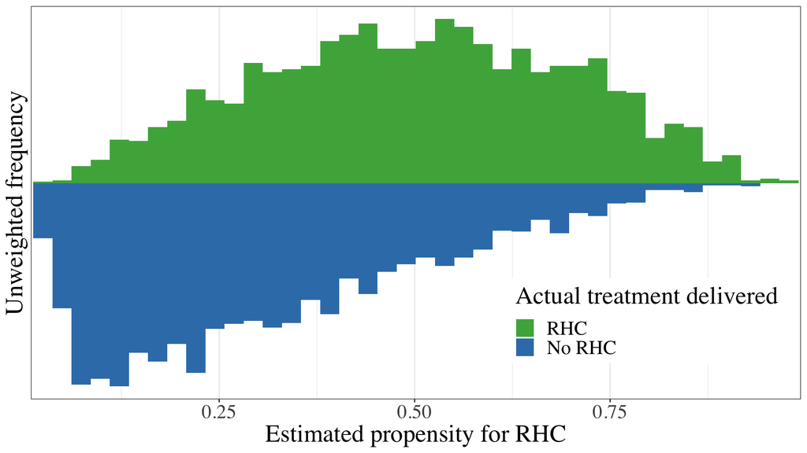

## Stratifying, applied to RHC

```r
# Use 0.025-width propensity bins
rhc_ps <-
  rhc_ps %>%
  mutate(ps_quantile = cut_width(ps_swang1, width = 0.025, center = 0.0125))

rhc_ps %>%
  count(swang1, ps_quantile) %>%
  pivot_wider(id_cols = ps_quantile,
              names_from = swang1,
              values_from = n,
              values_fill = 0) %>%
  print(n = Inf)
```

```
## # A tibble: 39 × 3
##    ps_quantile    `0`   `1`
##    <fct>        <int> <int>
##  1 [0,0.025]        8     0
##  2 (0.025,0.05]   110     2
##  3 (0.05,0.075]   178     6
##  4 (0.075,0.1]    238    13
##  5 (0.1,0.125]    193    23
##  6 (0.125,0.15]   203    34
##  7 (0.15,0.175]   179    27
##  8 (0.175,0.2]    174    42
##  9 (0.2,0.225]    190    46
## 10 (0.225,0.25]   173    57
## 11 (0.25,0.275]   146    57
## 12 (0.275,0.3]    150    71
```

[output cut: 27 more lines]

```r
# Calculate weights based upon strata size, treatment size, and strata-treatment size
rhc_ps <-
  left_join(rhc_ps,
            rhc_ps %>%
              count(ps_quantile, name = "stratum_size"),
            by = "ps_quantile") %>%
  left_join(rhc_ps %>%
              count(swang1, name = "treatment_size"),
            by = "swang1") %>%
  left_join(rhc_ps %>%
              count(swang1, ps_quantile, name = "stratum_treatment_size"),
            by = c("swang1", "ps_quantile")) %>%
  mutate(stratified_weight = stratum_size * treatment_size / stratum_treatment_size / n(),
         .keep = "unused")

# weight given to each observation in each group
rhc_ps %>%
  group_by(swang1, ps_quantile) %>%
  summarize(num = n(),
            wgt_per_obs = first(stratified_weight),
            wgt_total  = num * wgt_per_obs) %>%
  pivot_wider(id_cols = ps_quantile,
              names_from = swang1,
              values_from = c(num, wgt_per_obs, wgt_total))
```

```
## # A tibble: 39 × 7
##    ps_quantile  num_0 num_1 wgt_per_obs_0 wgt_per_obs_1 wgt_total_0 wgt_total_1
##    <fct>        <int> <int>         <dbl>         <dbl>       <dbl>       <dbl>
##  1 [0,0.025]        8    NA         0.619         NA           4.95        NA
##  2 (0.025,0.05]   110     2         0.630         21.3        69.3         42.7
##  3 (0.05,0.075]   178     6         0.640         11.7       114.          70.1
##  4 (0.075,0.1]    238    13         0.653          7.35      155.          95.6
##  5 (0.1,0.125]    193    23         0.693          3.58      134.          82.3
##  6 (0.125,0.15]   203    34         0.723          2.65      147.          90.3
##  7 (0.15,0.175]   179    27         0.713          2.91      128.          78.4
##  8 (0.175,0.2]    174    42         0.769          1.96      134.          82.3
##  9 (0.2,0.225]    190    46         0.769          1.95      146.          89.9
## 10 (0.225,0.25]   173    57         0.823          1.54      142.          87.6
## # … with 29 more rows
```

## Matching, applied to RHC

### Use `MatchIt` package

```r
library(MatchIt)
matched_rhc <- matchit(ps_formula, data = rhc, caliper = 0.025, std.caliper = FALSE)

matched_rhc
```

```
## A matchit object
##  - method: 1:1 nearest neighbor matching without replacement
##  - distance: Propensity score [caliper]
##              - estimated with logistic regression
##  - caliper: <distance> (0.025)
##  - number of obs.: 5735 (original), 3574 (matched)
##  - target estimand: ATT
##  - covariates: transhx, age, surv2md1, scoma1, hrt1, bili1, wtkilo1, dnr1, resp, income, cat1, cat2, psychhx, malighx, aps1, neuro, hema, ninsclas
```

```r
matched_rhc_pairs <-
  get_matches(matched_rhc, weights = "matched_weight")

head(matched_rhc_pairs)
```

```
##     id subclass matched_weight subjid swang1 dth30 transhx  age surv2md1 scoma1
## 1    2        1              1      2      1     0       1 78.2    0.755      0
## 2 3920        1              1   3920      0     1       0 78.8    0.407      9
## 3    5        2              1      5      1     1       0 67.9    0.437     41
## 4 1852        2              1   1852      0     1       0 64.1    0.594      9
## 5   10        3              1     10      1     0       0 48.4    0.669      0
## 6 2242        3              1   2242      0     0       0 51.5    0.481      0
##   hrt1 bili1 wtkilo1 dnr1 resp income cat1 cat2 psychhx malighx aps1 neuro hema
## 1  137  0.70    45.7    1    1      4    9    7       0       0   50     1    1
## 2  150  3.70    81.9    2    1      4    9    7       0       1   63     1    1
## 3  125  1.01    78.4    2    1      4    9    7       0       0   72     1    1
## 4   40  1.01    58.5    1    1      4    9    7       0       0   66     1    1
## 5  141  0.50    43.7    1    1      4    1    7       0       1   48     2    1
## 6  126  1.60    88.6    1    1      2    4    7       0       1   27     1    2
##   ninsclas distance
## 1        0    0.511
## 2        0    0.486
## 3        0    0.559
## 4        0    0.535
## 5        0    0.139
## 6        0    0.139
```

```r
rhc_ps <-
  left_join(rhc_ps,
            matched_rhc_pairs %>%
              select(subjid, matched_weight),
            by = "subjid") %>%
  mutate(matched_weight = ifelse(is.na(matched_weight), 0, matched_weight))
```

## IPW, applied to RHC

```r
rhc_ps <-
  rhc_ps %>%
  mutate(ip_weight = swang1 / ps_swang1 + (1 - swang1) / (1 - ps_swang1))
```

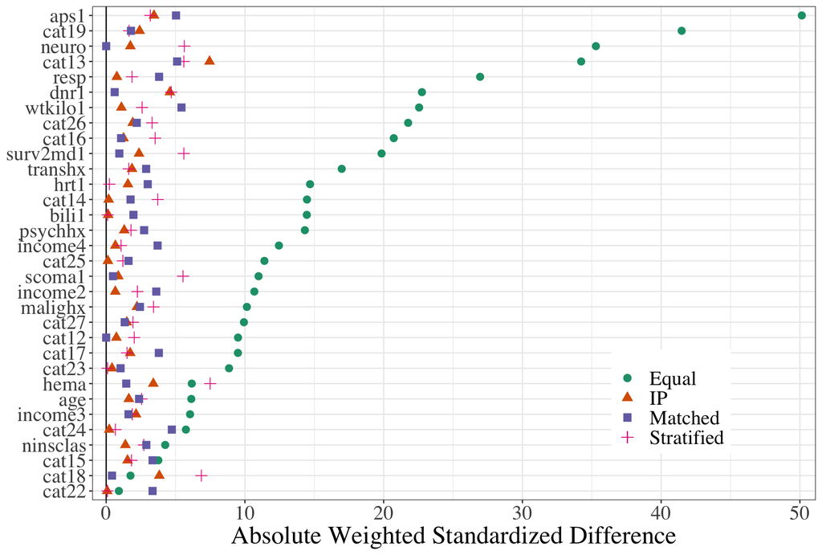

## Observed difference in outcome

```r
model_obs <- gam(dth30 ~ swang1, family = "binomial", data = rhc_ps)

obs_diff <-
  predict(model_obs, type = "response", newdata = rhc_ps %>% slice(1) %>% mutate(swang1 = 1)) -
  predict(model_obs, type = "response", newdata = rhc_ps %>% slice(1) %>% mutate(swang1 = 0))

obs_diff
```

```
##      1
## 0.0736
```

## RHC analysis, adjusting for PS in model

Use generalized additive models (GAMs) to equip propensity score with a smoothing spline. Implemented in `mgcv::gam`.

```r
# Parametric component for treatment; non-parametric component for ps
model_adjust_ps <- gam(dth30 ~ swang1 + s(ps_swang1), family = "binomial", data = rhc_ps)

# Estimated treatment effect is average predicted response if all were treated
resp_rhc <- predict(model_adjust_ps, type = "response", newdata = rhc_ps %>% mutate(swang1 = 1))
resp_not_rhc <- predict(model_adjust_ps, type = "response", newdata = rhc_ps %>% mutate(swang1 = 0))
adjusted_diff <-
  mean(resp_rhc) -
  mean(resp_not_rhc)

adjusted_diff
```

```
## [1] 0.0741
```

`resp_rhc - resp_not_rch` versus `ps_swang`:

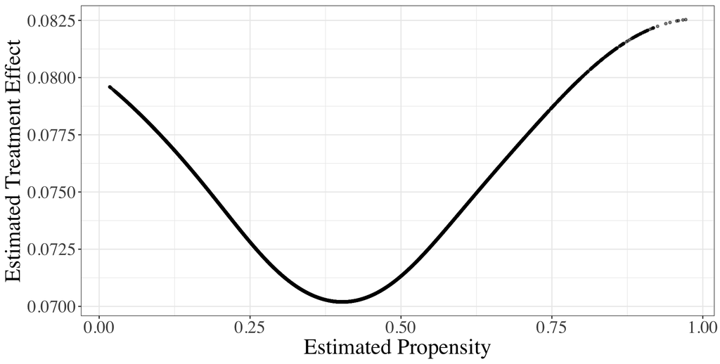

## RHC analysis, stratifying by PS

```r
# Fit GLM weighting by stratum weights
model_stratified <- glm(dth30 ~ swang1, family = "binomial", weights = stratified_weight, data = rhc_ps)

# Estimated treatment effect is average predicted response if all were treated
# versus if all were untreated
stratified_diff <-
  predict(model_stratified, type = "response", newdata = rhc_ps %>% slice(1) %>% mutate(swang1 = 1)) -
  predict(model_stratified, type = "response", newdata = rhc_ps %>% slice(1) %>% mutate(swang1 = 0))
stratified_diff
```

```
##     1
## 0.085
```

```r
# Same as taking difference in weighted means
rhc_ps %>%
  group_by(swang1) %>%
  summarize(mean_dth30 = weighted.mean(dth30, stratified_weight)) %>%
  arrange(swang1) %>%
  pull(mean_dth30) %>%
  diff()
```

```
## [1] 0.085
```

## RHC analysis, matching by PS

```r
matched_diff <-
  rhc_ps %>%
  group_by(swang1) %>%
  summarize(mean_dth30 = weighted.mean(dth30, matched_weight)) %>%
  arrange(swang1) %>%
  pull(mean_dth30) %>%
  diff()

matched_diff
```

```
## [1] 0.0783
```

## RHC analysis, weighting by IP

```r
model_ipw <- glm(dth30 ~ swang1, family = "binomial", weights = ip_weight, data = rhc_ps)

# Estimated treatment effect is average predicted response if all were treated
# versus if all were untreated
ipw_diff <-
  predict(model_ipw, type = "response", newdata = rhc_ps %>% slice(1) %>% mutate(swang1 = 1)) -
  predict(model_ipw, type = "response", newdata = rhc_ps %>% slice(1) %>% mutate(swang1 = 0))

ipw_diff
```

```
##      1
## 0.0711
```

## Comparison

| Method | Result |
| --- | --- |
| Observed | 0.0736 |
| Adjusted | 0.0741 |
| Stratified | 0.0850 |
| Matched | 0.0783 |
| IPW | 0.0711 |

## Inference

In a modeling framework, it is fairly straightforward to conduct inference. Subtle issue is that because propensities are estimated, standard variance estimates will likely be too small. The sandwich variance estimator will tend to give more accurate inference:

```r
# regular variance estimator
sqrt(diag(vcov(model_ipw)))
```

```
## (Intercept)      swang1
##      0.0283      0.0395
```

```r
# vcovHC from sandwich package for robust variance estimator
sqrt(diag(vcovHC(model_ipw, type = "HC")))
```

```
## (Intercept)      swang1
##      0.0418      0.0696
```

Can also use the bootstrap to estimate variance and conduct inference

## Assumptions

Propensity score approaches depend upon the validity of certain assumptions:

- Ignorability: No unmeasured confounding
- Consistency: Outcome we observe is equal to outcome in counterfactual world
- Positivity: \(0 < \Pr(Z=1|X) < 1\) for all \(X\)
- Propensity score model is correctly specified

## Instability of IPW

Sometimes IP weights will be very large, e.g. \(Z=1\) and \(e(X)\approx 0\).

- Can trim weights: exclude observations with \(e_i < \alpha\) or \(e_i > 1- \alpha\)
- More stable weighting schemes exist:
  - Overlap weights (F. Li, Thomas, and Li (2019)): \(w_i = Z_i(1-e_i) + (1-Z_i)e_i\)
  - Matching weights (L. Li and Greene (2013)): \(w_i = \dfrac{\min(1-e_i, e_i)}{Z_ie_i + (1-Z_i)(1-e_i)}\)

## Estimands

An estimand is defined as the true value of a parameter in a target population. Different schemes may yield different estimands

- The ATE is the expected difference in the outcome if everyone got one treatment versus if everyone got the other treatment
- The ATT (Average Treatment effect among Treated) is the expected difference in the outcome if the population of observations who were treated got one treatment versus if that same population got the other treatment
- Overlap weights estimate neither ATE nor ATT

## More things to read

Good introductory / review articles for issues related to propensity analyses:

Austin (2009), Austin and Stuart (2015), Franklin et al. (2017)

http://www2.stat.duke.edu/~fl35/teaching/640/Chap3.4_observational_weighting.pdf

One of the first papers that identifies propensity score as a balancing score:

Rosenbaum and Rubin (1983)

Other helpful articles:

Joffe et al. (2004), Lunceford and Davidian (2004)

## References

Austin, Peter C. 2009. “Balance Diagnostics for Comparing the Distribution of Baseline Covariates Between Treatment Groups in Propensity-Score Matched Samples.” *Statistics in Medicine* 28 (25): 3083–3107.

Austin, Peter C, and Elizabeth A Stuart. 2015. “Moving Towards Best Practice When Using Inverse Probability of Treatment Weighting (IPTW) Using the Propensity Score to Estimate Causal Treatment Effects in Observational Studies.” *Statistics in Medicine* 34 (28): 3661–79.

Connors, Alfred F, Theodore Speroff, Neal V Dawson, Charles Thomas, Frank E Harrell, Douglas Wagner, Norman Desbiens, et al. 1996. “The Effectiveness of Right Heart Catheterization in the Initial Care of Critically III Patients.” *Jama* 276 (11): 889–97.

Flury, Bernhard K, and Hans Riedwyl. 1986. “Standard Distance in Univariate and Multivariate Analysis.” *The American Statistician* 40 (3): 249–51.

Franklin, Jessica M, Wesley Eddings, Peter C Austin, Elizabeth A Stuart, and Sebastian Schneeweiss. 2017. “Comparing the Performance of Propensity Score Methods in Healthcare Database Studies with Rare Outcomes.” *Statistics in Medicine* 36 (12): 1946–63.

Joffe, Marshall M, Thomas R Ten Have, Harold I Feldman, and Stephen E Kimmel. 2004. “Model Selection, Confounder Control, and Marginal Structural Models: Review and New Applications.” *The American Statistician* 58 (4): 272–79.

Li, Fan, Laine E Thomas, and Fan Li. 2019. “Addressing Extreme Propensity Scores via the Overlap Weights.” *American Journal of Epidemiology* 188 (1): 250–57.

Li, Liang, and Tom Greene. 2013. “A Weighting Analogue to Pair Matching in Propensity Score Analysis.” *The International Journal of Biostatistics* 9 (2): 215–34.

Lunceford, Jared K, and Marie Davidian. 2004. “Stratification and Weighting via the Propensity Score in Estimation of Causal Treatment Effects: A Comparative Study.” *Statistics in Medicine* 23 (19): 2937–60.

Rosenbaum, Paul R, and Donald B Rubin. 1983. “The Central Role of the Propensity Score in Observational Studies for Causal Effects.” *Biometrika* 70 (1): 41–55.